# projeto_02

## Autor

Carlos Augusto Jardim Chiarelli **165685**

$$ $$

```python
# bibliotecas
import  pandas            as pd
import  numpy             as np
import  matplotlib.pyplot as plt
import  sympy             as sp
from    scipy             import integrate, optimize
from    numpy             import pi, sqrt, cos, sin
from    platform          import python_version
from    warnings          import filterwarnings
from    matplotlib.ticker import FormatStrFormatter
from    IPython.display   import Image

def mostra_valor(var, nomeVar, unidade, casasDec=None):

    printar = '\n%s = %.numCasasf [%s]\n'

    if casasDec:
        printar = printar.replace('numCasas', str(casasDec))
    else:
        printar = printar.replace('numCasas', str(2))

    print(printar % (nomeVar, var, unidade))

def cria_tabela():
    "{'Kf':np.nan, 'Kfs':np.nan, 'Se':np.nan, 'd':np.nan}"
    return pd.DataFrame({'Kf':[np.nan], 'Kfs':[np.nan], 'Se':[np.nan], 'd':[np.nan]})

def adiciona_linha(df, Kf, Kfs, Se, d):
    "Adiciona uma linha a tabela"
    ultima = df.shape[0]
    df.loc[ultima+1] = [Kf, Kfs, Se, d]
    return df

def obtem_diametros_df(d1_df, d2_df, d3_df):
    d1, d2, d3 = d1_df.loc[6,'d'], d2_df.loc[6,'d'], d3_df.loc[6,'d']
    return pd.DataFrame({'diametro':[1,2,3], 'valor [m]':[d1,d2,d3]})

def mostra_dados(dic, nome):
    ver = pd.DataFrame(dic)
    ver.index.name = nome
    return round(ver,1)

def plota_diagrama():
    plt.rcParams.update({'font.size': 16}) # tamanho da fonte

    titulos = ['Cisalhamento no plano Y-X', 'Cisalhamento no plano Z-X',
               'Momento no plano Y-X',      'Momento no plano Z-X',
               'Theta Y-X (graus)',         'Theta Y-Z (graus)']

    eixo_y = [cis_yx, cis_zx, M_yx, M_zx, theta_y, theta_z]
    cor    = ['b', 'r']*2 + ['g'] + ['g']
    x = np.linspace(0, L[-1], len(L))

    #fig, axes = plt.subplots(nrows=3, ncols=2, figsize=(20, 10))
    fig, axes = plt.subplots(nrows=3, ncols=2, figsize=(18, 12))

    # gerando e plotando
    for titulo, y, cor, ax in zip(titulos, eixo_y, cor, axes.flat):

        ax.xaxis.set_major_formatter(FormatStrFormatter('%.2f'))

        ax.fill_between(x, y, color=cor, alpha=0.1)
        ax.plot(L, y, color=cor)

        ax.set_title(titulo)
        ax.hlines(0, 0, L[-1], colors='black', linewidth=3, linestyle = 'dashed')
        ax.grid(color = 'b', alpha = 0.5, linestyle = 'dashed', linewidth = 0.5)

    fig.tight_layout() # ajusta espaço entre gráficos
    plt.show()


filterwarnings('ignore')               # remove warnings
plt.rcParams.update({'font.size': 16}) # tamanho da fonte (gráficos)

print('\nVersão da Linguagem Python usada neste relatório:', python_version())
```

```
Versão da Linguagem Python usada neste relatório: 3.7.6
```

$$ $$

# **Projeto 02**

A figura abaixo mostra um eixo de transmissão composto por duas engrenagens na região central e com rolamentos montados nas extremidades.

$$ $$

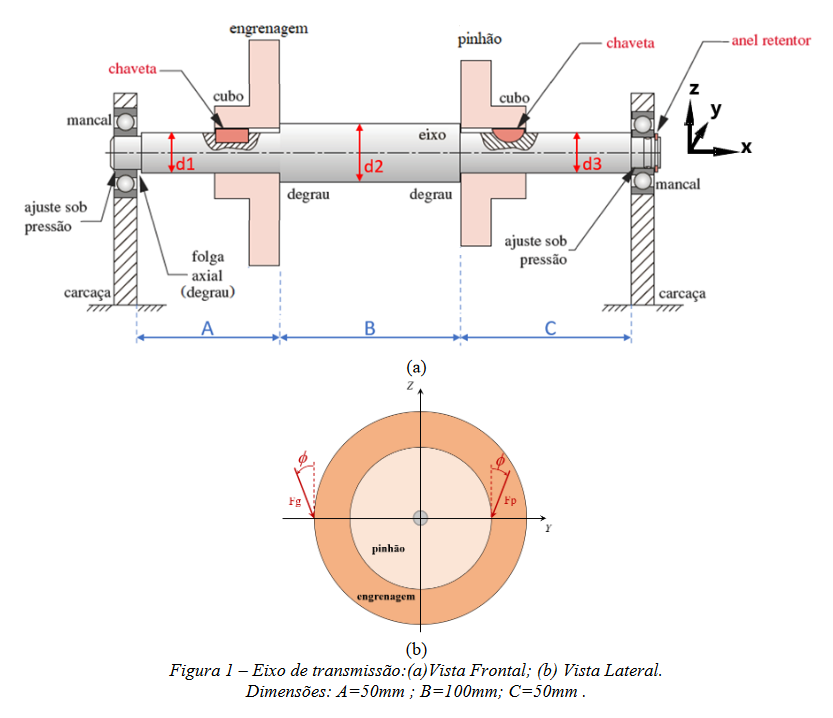

```python
Image('../dados/imagens/proj01_fig_projeto01.PNG')
```

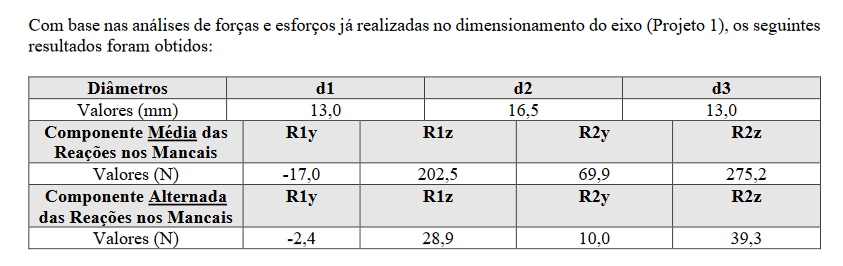

```python
Image('../dados/imagens/proj02_fig_projeto01.PNG')
```

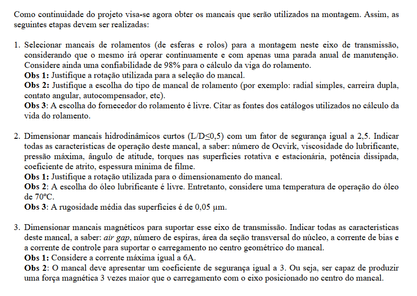

```python
Image('../dados/imagens/proj02_fig_projeto02.PNG')
```

## Dados:

$$ $$

- potência $3$HP variando entre 1500 a 2000 RPM (cíclico) $$ $$
- $K_{R} \rightarrow 98$ % $$ $$

```python
# propriedades do sistema

omega_min = 1500          # velocidade angular [RPM]
omega_max = 2000          # velocidade angular [RPM]
P         = 3             # potência [HP]
De, Dp    = 150e-3, 80e-3 # diâmetros engrenagem e pinhão [m]
Re, Rp    = De/2,   Dp/2  # raios     engrenagem e pinhão [m]
C_conf    = 0.98          # percentual
Nf        = 2.5
Temp_op   = 70            # °C

rug_med_sup = 0.05e-6     # m

d_eixo    = {1: 13e-3,    # metros
             2: 16.5e-3,
             3: 13e-3}

A, B, C   = 50e-3, 100e-3, 50e-3 # [m]

Fg, Fp, Ra, Rd = {}, {}, {}, {}

# forças na engrenagem e pinhão (EXE 01) [N]
Fg['medio'], Fp['medio'] = {'y':60.5, 'z':-166.2}, {'y':-113.4, 'z':-311.5}
Fg['alt'],   Fp['alt']   = {'y':8.6,  'z':-23.7},  {'y':-16.2,  'z':-44.5}

# forças nos mancais [N]
Ra['medio'], Rd['medio'] = {'y':-17,  'z':202.5},  {'y': 69.9,  'z': 275.2}
Ra['alt'],   Rd['alt']   = {'y':-2.4, 'z':28.9},   {'y': 10,    'z': 39.3}
```

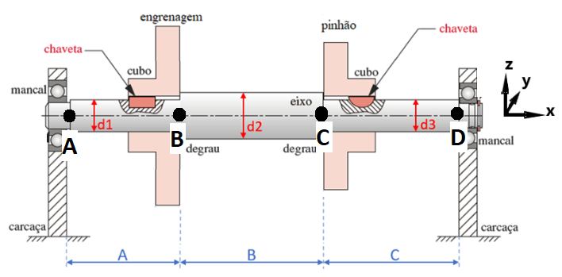

```python
Image('../dados/imagens/proj01_fig_projeto02.PNG')
```

$$$$

# **01)**

$$$$

Para todos os 3 projetos desenvolvidos será projetado o mancal para o lado com maior carregamento e então duplicado para o outro lado.

Será feito um escalonamento de 25% em relação ao eixo para encontrar o diâmetro interno do mancal. Nisso é considerado que os diâmetros $d_{1}$ e $d_{3}$ são encostos.

O projeto será feito com o carregamento do mancal da extremidade direita.

A rotação máxima para o dimensionamento será 2000 rpm, admitindo assim o pior caso.

$$$$

$$$$

Primeiro é necessário calcular a deflexão pro mancal. Caso seja um ângulo acima de $0.04°$ é necessário um mancal que suporte deflexões nos eixo y e z. $$$$

```python
# escalonamento diâmetro
d_mancal = d_eixo[3] * 0.75
#d_mancal = np.floor(d_mancal*1e3) # [mm] (arrendonda pra baixo)
d_mancal = np.ceil(d_mancal*1e3) # [mm] (arrendonda pra baixo)

mostra_valor(d_mancal, 'Diâmetro mancal', 'mm')
```

```
Diâmetro mancal = 10.00 [mm]
```

```python
Fa, Fm = Rd['alt'], Rd['medio']

# força resultante
Fy = Fa['y'] + Fm['y']
Fz = Fa['z'] + Fm['z']
Fr = sqrt(Fy**2 + Fz**2)
Fa = 0

mostra_valor(Fr, 'Força radial resultante', 'N')
```

```
Força radial resultante = 324.49 [N]
```

```python
# aco sae 1045
E = 200e9
#I_eixo = pi*(d_eixo[3]**4)/64

L = np.arange(0, A+B+C*1.1, 10e-4) # comprimento em X

def I_eixo(d):
    return pi*(d**4)/64

def V_y(x):
    if x < A:
        return Ra_y
    elif x >= A and x < (A+B):
        return Ra_y + Fg_y
    elif x >= (A+B) and x < (A+B+C):
        return Ra_y + Fg_y + Fp_y
    else:
        return Ra_y + Fg_y + Fp_y + Rd_y

def V_z(x):
    if x < A:
        return Ra_z
    elif x >= A and x < (A+B):
        return Ra_z + Fg_z
    elif x >= (A+B) and x < (A+B+C):
        return Ra_z + Fg_z + Fp_z
    else:
        return Ra_z + Fg_z + Fp_z + Rd_z

# deflexao viga
def M_z(x):
    if x < A:
        return Ra_z*x
    elif x >= A and x < (A+B):
        return Ra_z*x + Fg_z*(x-A)
    elif x >= (A+B) and x < (A+B+C):
        return Ra_z*x + Fg_z*(x-A) + Fp_z*(x-A-B)
    else:
        return Ra_z*x + Fg_z*(x-A) + Fp_z*(x-A-B) + Rd_z*(x-A-B-C)

def M_y(x):
    if x < A:
        return Ra_y*x
    elif x >= A and x < (A+B):
        return Ra_y*x + Fg_y*(x-A)
    elif x >= (A+B) and x < (A+B+C):
        return Ra_y*x + Fg_y*(x-A) + Fp_y*(x-A-B)
    else:
        return Ra_y*x + Fg_y*(x-A) + Fp_y*(x-A-B) + Rd_y*(x-A-B-C)

def theta(x, M_int):
    if x < A:
        return M_int/(I_eixo(d_eixo[1])*E)
    elif x >= A and x < (A+B):
        return M_int/(I_eixo(d_eixo[2])*E)
    elif x >= (A+B): # and x < (A+B+C):
        return M_int/(I_eixo(d_eixo[3])*E)

Fg_y, Fp_y = Fg['medio']['y']+Fg['alt']['y'], Fp['medio']['y']+Fp['alt']['y']
Ra_y, Rd_y = Ra['medio']['y']+Ra['alt']['y'], Rd['medio']['y']+Rd['alt']['y']

Fg_z, Fp_z = Fg['medio']['z']+Fg['alt']['z'], Fp['medio']['z']+Fp['alt']['z']
Ra_z, Rd_z = Ra['medio']['z']+Ra['alt']['z'], Rd['medio']['z']+Rd['alt']['z']

# esforço cortante (cisalhamento)
cis_yx = list(map(V_y, L))
cis_zx = list(map(V_z, L))

# momento fletor (flexão)
M_yx = list(map(M_y, L))
M_zx = list(map(M_z, L))

# theta (deflexão)
M_zx_int = integrate.cumtrapz(M_zx, L, initial=0)
M_yx_int = integrate.cumtrapz(M_yx, L, initial=0)

theta_z = [theta(l, m_int)*180/pi for l, m_int in zip(L, M_zx_int)]
theta_y = [theta(l, m_int)*180/pi for l, m_int in zip(L, M_yx_int)]

M_yx = list(map(M_y, L))
M_zx = list(map(M_z, L))
```

$$$$

Abaixou temos relação com o ângulo de deflexão e o momento fletor. $$$$ $$ \frac{d\theta}{dx} = \frac{M}{EI} $$ $$$$

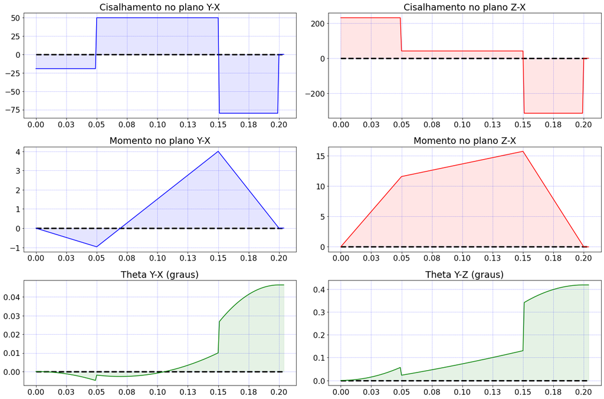

```python
plota_diagrama()
```

$$$$

Acima vemos que é necessário um mancal que suporte deflexões em y e z, pois pode acontecer de ocorrer uma deflexão $> 0.04°$ no mancal da direita.

A descontinuidade acima em $\theta$ (graus) é devido a mudança brusca dos diâmetros nos eixos 1, 2 e 3.

Utilizando o **catálogo SKF**, foi escolhido o **mancal rolamento autocompensador de esferas**. Esse mancal permite deflexões em Y e Z, além de que não existir esforços axiais (apenas radiais).

Para de rolos será adotado o **mancal rolamento radial autocompensador de rolos** pelos mesmos motivos dos de esferas, não existe carga axial mas exoste deflexão em y e z. $$$$

$$$$

## 1.1) Rolamento de Esferas

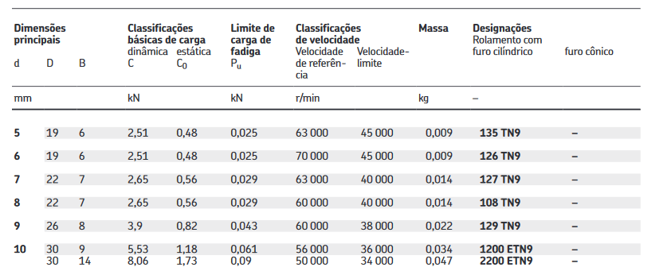

```python
Image('../dados/imagens/proj02_fig_projeto03.PNG')
```

"*4.1 Rolamentos autocompensadores de esferas $d$ de 5 a 30 mm*" (página 552 catálogo SKF)

**Fonte:** *Catálogo SKF* $$$$

```python
mostra_valor(0.5*(9+26), 'Diâmetro médio', 'mm')
```

```
Diâmetro médio = 17.50 [mm]
```

$$$$

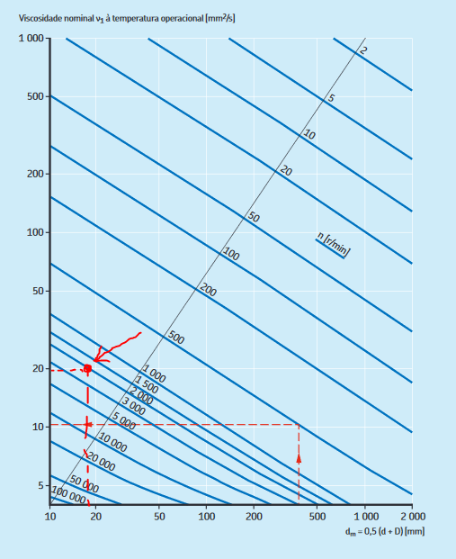

```python
Image('../dados/imagens/proj02_fig_projeto04_3.PNG')
```

**Fonte:** *Catálogo SKF* $$$$

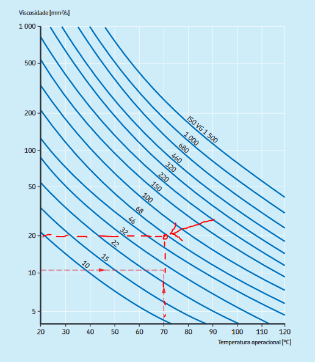

```python
Image('../dados/imagens/proj02_fig_projeto04_4.PNG')
```

**Fonte:** *Catálogo SKF* $$$$

```python
Sl = 36e3   # RPM
C  = 5.53e3  # N
C0 = 1.18e3 # N
```

$$$$

Como o carregamento axial é zero, chegamos que: $$$$

- $V=1$ $$$$
- $X=1$ $$$$
- $Y=0$ $$$$

```python
V = 1
X = 1
Y = 0

P = X*V*Fr + Y*Fa

mostra_valor(P, 'P', 'N')
```

```
P = 324.49 [N]
```

$$$$

A vida $L_{10}$ deve ser calculada de acordo com o catálogo escolhido. $$$$ $$ L_{p} = a_{1}a_{SKF} \left( \frac{C}{P} \right)^3 $$ $$$$

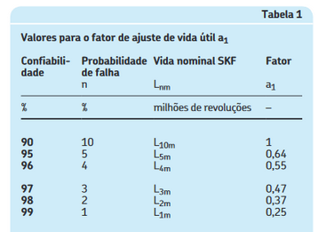

```python
Image('../dados/imagens/proj02_fig_projeto05.PNG')
```

**Fonte:** *Catálogo SKF* $$$$

```python
a_skf = 1    # fator de modificação de vida útil SKF (estimativa no DIAGRAMA SKF)
a1    = 0.37 # 98% de confiabilidade

Lp  = a1*a_skf*(C/P)**3 # milhões de revoluções
Lp *= 1e6

mostra_valor(Lp*1e-6, 'Lp', 'milhões de revoluções')
```

```
Lp = 1831.34 [milhões de revoluções]
```

```python
omega = 2000

mostra_valor(omega, 'Velocidade funcionamento', 'RPM')
```

```
Velocidade funcionamento = 2000.00 [RPM]
```

$$$$

Vamos suport que o eixo funciona **24x7** (24hrs por dia, 7 dias na semana) sem interrupções. $$$$

```python
rot_porHora = omega * 60
rot_porDia  = rot_porHora * 24

duracao_dias = Lp/rot_porDia
duracao_dias = np.floor(duracao_dias)

mostra_valor(duracao_dias, 'Duração do mancal de esferas', 'dias')
```

```
Duração do mancal de esferas = 635.00 [dias]
```

$$$$

## 1.2) Rolamento de Rolos

$$$$

Será utilizado o **catálogo da NSK**. $$$$

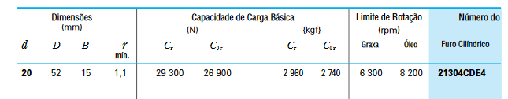

```python
Image('../dados/imagens/proj02_fig_projeto06.PNG')
```

```python
Sl = 8200   # RPM
C  = 29.3e3 # N
C0 = 26.9e3 # N

V = 1
X = 1
Y = 0

P = X*V*Fr + Y*Fa

mostra_valor(P, 'P', 'N')

a_skf = 1    # fator de modificação de vida útil SKF (estimativa no DIAGRAMA SKF)
a1    = 0.37 # 98% de confiabilidade

Lp  = a1*a_skf*(C/P)**3 # milhões de revoluções
Lp *= 1e6

mostra_valor(Lp*1e-6, 'Lp', 'milhões de revoluções')

omega = 2000

mostra_valor(omega, 'Velocidade funcionamento', 'RPM')

rot_porHora = omega * 60
rot_porDia  = rot_porHora * 24

duracao_dias = Lp/rot_porDia
duracao_dias = np.floor(duracao_dias)

mostra_valor(duracao_dias, 'Duração do mancal de esferas', 'dias')
```

```
P = 324.49 [N]


Lp = 272394.00 [milhões de revoluções]


Velocidade funcionamento = 2000.00 [RPM]


Duração do mancal de esferas = 94581.00 [dias]
```

$$$$

Acima vemos que o mancal com rolos, com o menor diâmetro disponibilizado no catálogo, fornece um tempo muito alto para o projeto, logo será escolhido o **mancal de esferas autocompensador**. $$$$

$$$$

# **02)**

$$$$

## Dados:

$$$$

## Definir:

$$$$

- número de Ocvirk $$$$
- viscosidade do lubrificante $$$$
- pressão máxima $$$$
- ângulo de altitude $$$$
- torques nas superfícies rotativa e estacionária $$$$
- potência dissipada $$$$
- coeficiente de atrito $$$$
- espessura mínima do filme $$$$

$$$$

- O diâmetro do mancal será o mesmo do eixo pois ele envolve ("abraça") o eixo. $$$$

```python
d_mancal = d_eixo[3]
#d_mancal = np.floor(d_mancal*1e3) # [mm] (arrendonda pra baixo)

mostra_valor(d_mancal*1e3, 'Diâmetro mancal', 'mm')
```

```
Diâmetro mancal = 13.00 [mm]
```

$$$$

- Cálculo da velocidade tangencial $U$. $$$$

```python
n_linha = omega/60
U       = pi*d_mancal*n_linha

mostra_valor(n_linha, "n'", 'rps ou Hz')
mostra_valor(U,       'Velocidade tangencial', 'm/s')
```

```
n' = 33.33 [rps ou Hz]


Velocidade tangencial = 1.36 [m/s]
```

$$$$

- Cálculo da folga diametral e folga radial.
  - será adotado a relação **razão folga diametral/diâmetro** $= 0.0005$ como sugerido no *Norton* (livro texto). $$$$

```python
Cd = d_mancal*0.0005
#Cd = d_mancal*0.0017
#Cd = d_mancal*0.00017
#Cd = d_mancal*0.001
Cr = Cd/2

mostra_valor(Cd*1e6, 'Cd', 'micro metro')
```

```
Cd = 6.50 [micro metro]
```

$$$$

Obtenção do comprimento axial do mancal a partir da razão $\frac{L}{D}$. $$$$

```python
l = d_mancal*0.5

mostra_valor(l*1e3, 'largura', 'mm')
```

```
largura = 6.50 [mm]
```

```python
O_n = 30

epsilon_x = 0.21394 + 0.38517*np.log10(O_n) - 0.0008*(O_n - 60)

mostra_valor(epsilon_x, 'Epsilon_x', 'adimensional', 3)
```

```
Epsilon_x = 0.807 [adimensional]
```

```python
k_epsilon = O_n/(4*pi)

mostra_valor(k_epsilon, 'k_epsilon', 'adimensional')
```

```
k_epsilon = 2.39 [adimensional]
```

```python
#visc_lub = (Nf*Fr*Cr**2)/(k_epsilon*U*l**3)
visc_lub = (Fr*Cr**2)/(k_epsilon*U*l**3)

mostra_valor(visc_lub, 'Viscosidade lubrificante (dinâmica)', 'Pa.s', 6)
mostra_valor(visc_lub*1e3, 'Viscosidade lubrificante (dinâmica)', 'cP', 4)
```

```
Viscosidade lubrificante (dinâmica) = 0.003840 [Pa.s]


Viscosidade lubrificante (dinâmica) = 3.8401 [cP]
```

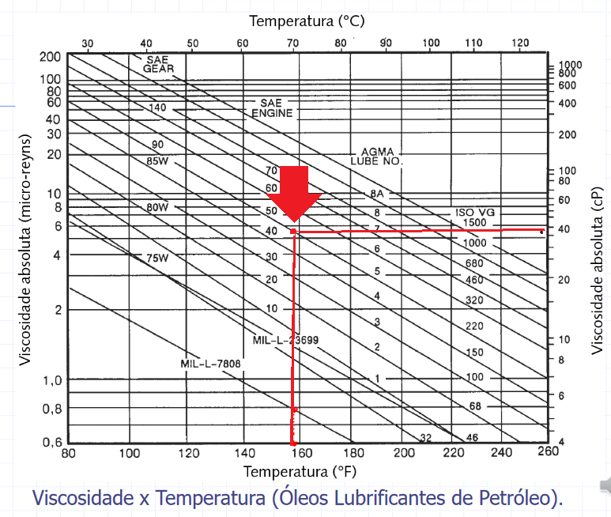

```python
Image('../dados/imagens/proj02_fig_projeto04_2.PNG')
```

$$$$

```python
############## pressão média filme de óleo ##############

p_med = Fr/(l*d_mancal) # Pa

mostra_valor(p_med*1e-6, 'Pressão média', 'MPa', 3)

# ângulo theta máx para pressão máxima
raiz_aux      = sqrt(1+24*epsilon_x**2)
theta_max_rad = np.arccos((1-raiz_aux)/(4*epsilon_x))
theta_max     = theta_max_rad * 180/pi

mostra_valor(theta_max, 'Theta máx (pressão máx)', 'graus')

############## pressão máxima ##############

visc_lub_oleo = visc_lub # Pa.s
z = 0
r = 0.5

num1 = (visc_lub_oleo*U)/(r*Cr**2)
num2 = (l**2/4 - z**2)
num3 = (3*epsilon_x*sin(theta_max_rad))/(1 + epsilon_x*cos(theta_max_rad))**3

p_max = num1*num2*num3

mostra_valor(p_max*1e-6, 'Pressão máx', 'MPa')

############## ângulo de equilíbrio ##############

phi = np.arctan((pi*sqrt(1-epsilon_x**2))/(4*epsilon_x))

mostra_valor(phi*180/pi, 'Ângulo de equilíbrio', 'graus')

############## torque da parte estacionária ##############

num = visc_lub_oleo*(d_mancal**3)*l*n_linha*(pi**2)
den = Cd*(1-epsilon_x**2)**1/2
Ts  = num/den

mostra_valor(Ts, 'Torque estacionário', 'N.m', 4)

############## torque da parte rotacional ##############

exc = epsilon_x*Cr
Tr  = Ts + Fr*exc*sin(phi)

mostra_valor(Tr, 'Torque rotacional', 'N.m', 4)

############## perda de potência no mancal ##############

perca_w = 2*pi*Tr*n_linha

mostra_valor(perca_w, 'Perca de potência mancal', 'J/s')

############## cálculo do coeficiente de atrito ##############

mi = 2*Tr/(Fr*d_mancal)

mostra_valor(mi, 'Coeficiente de atrito', 'adimensional', 3)
```

```
Pressão média = 3.840 [MPa]


Theta máx (pressão máx) = 162.46 [graus]


Pressão máx = 0.62 [MPa]


Ângulo de equilíbrio = 29.90 [graus]


Torque estacionário = 0.0159 [N.m]


Torque rotacional = 0.0163 [N.m]


Perca de potência mancal = 3.42 [J/s]


Coeficiente de atrito = 0.008 [adimensional]
```

```python
h_min = Cr*(1-epsilon_x)

mostra_valor(h_min*1e7, 'Espessura mínima filme', 'E-7 m')
```

```
Espessura mínima filme = 6.28 [E-7 m]
```

```python
# espessura do filme deve ser 4x menor

h_min2 = 4 * rug_med_sup

mostra_valor(h_min2*1e7, 'h_min', 'E-7 m')
```

```
h_min = 2.00 [E-7 m]
```

```python
# Logo

epsilon = -(h_min2/Cr-1)

mostra_valor(epsilon, 'Epsilon', 'adimensional', 3)
```

```
Epsilon = 0.938 [adimensional]
```

```python
def myfunc(O_n):
    return 0.21394 + 0.38517*np.log10(O_n) - 0.0008*(O_n - 60) - epsilon

result = optimize.fsolve(myfunc, x0=40)
O_n    = result[0]

mostra_valor(O_n, 'Ocvirk', 'adimensional')
```

```
Ocvirk = 86.18 [adimensional]
```

```python
k_epsilon = O_n/(4*pi)

mostra_valor(k_epsilon, 'k_epsilon', 'adimensional')
```

```
k_epsilon = 6.86 [adimensional]
```

```python
P = (visc_lub*k_epsilon*U*l**3)/(Cr**2)
```

```python
Nf_proj = P/Fr

mostra_valor(Nf_proj, 'Coeficiente de segurança', 'adimensional')
```

```
Coeficiente de segurança = 2.87 [adimensional]
```

$$$$

# **03)**

$$$$

$$$$

## Dados:

$$$$

- corrente máx = $6$ A $$$$
- $N_{f}=3$ (força magnética 3x maior que o carregamento) $$$$
- $i_{0}=3$ A $$$$

```python
A      = 3e-4 *1
N      = 200  *1.9
g0     = 1e-3 *0.7
i0     = 3
ix_max = 3
i1     = i0 + ix_max
i2     = i0 - ix_max
Nf     = 3
mi_zero = 4*pi*1e-7
x = 0

Km = mi_zero*A*N**2

ix = sp.symbols('ix')
i1 = i0 + ix
i2 = i0 - ix
x  = 0

# resolvendo a equação não linear
ix_sol = sp.solve(Km/4*(i1**2/(g0-x)**2 - i2**2/(g0+x)**2) - Nf*Fr, ix)

mostra_valor(ix_sol[0], 'ix', 'A')
```

```
ix = 2.92 [A]
```

```python
# diâmetro do fio de cobre da bobina
d_fio = 0.1e-3 # [m]
```

```python
# vamos assumir que a circunferencia do eixo deve ser igual 5x a largura núcleo da bobina
r = A/(N*d_fio)*5 / (2*pi)
d = np.ceil(2*r*1e3)

mostra_valor(d, 'Diâmetro eixo', 'mm', 5)
```

```
Diâmetro eixo = 13.00000 [mm]
```

```python
mostra_valor(A*1e4, 'Área núcleo magnético', 'cm²')
mostra_valor(N, 'N° espiras', 'unidades')
mostra_valor(g0*1e3, 'g0', 'mm')
mostra_valor(i0, 'i0', 'A')
```

```
Área núcleo magnético = 3.00 [cm²]


N° espiras = 380.00 [unidades]


g0 = 0.70 [mm]


i0 = 3.00 [A]
```